```r
# inputs - original data (File size is huge)
# fn_search = 'searches.csv.xz'
# fn_products = 'products.csv.xz'
# fn_amazon = 'amazon_private_label.csv.xz'
#
# search = read_csv(fn_search)
# products = read_csv(fn_products)
# amazon_label = read_csv(fn_amazon)
```

# What Characterizes a Products Placement on Amazon?

## Introduction

Our dataset is a subset of search queries on Amazon from a GitHub repository created by The Markup on October 14, 2021.

The actual data retrieval was done on January 21st, 2021 from a single location, Washington D.C.

Given the author’s standards regarding amazon brands, the data collected was narrowed to 3,492 different queries and accumulated different information based on each query. We are interested in this data because it relates Amazon products and their quality to those of Amazon partners and independent retailers.

Using this data, we came up with a research question to help us explore the similarities and differences between these groups: How do products from Amazon compare to similar products from either partners of Amazon or independent sellers in terms of reviews, quality, and position on the website?

## Data

```r
# Summarizing Star and Reviews averages
summary = amazon %>%
  select(-search_term) %>%
  summarize(amazon = mean(amazon_stars),
            partner = mean(partner_stars),
            third_party = mean(third_party_stars))

summary1 = amazon %>%
  select(-search_term) %>%
  summarize(amazon = mean(amazon_reviews),
            partner = mean(partner_reviews),
            third_party = mean(third_party_reviews))

prop_third_party = amazon %>%
  filter(third_party_stars < partner_stars & third_party_stars < amazon_stars)

prop_partner= amazon %>%
  filter(partner_stars < third_party_stars & partner_stars < amazon_stars)

prop_amazon = amazon %>%
  filter(amazon_stars < partner_stars & amazon_stars < third_party_stars)

tibble(
  prop_amazon = nrow(prop_amazon) / nrow(amazon),
  prop_third = nrow(prop_third_party) / nrow(amazon),
  prop_partner = nrow(prop_partner) / nrow(amazon)
)
```

```
## # A tibble: 1 × 3
##   prop_amazon prop_third prop_partner
##         <dbl>      <dbl>        <dbl>
## 1       0.318      0.283        0.158
```

### Question 1

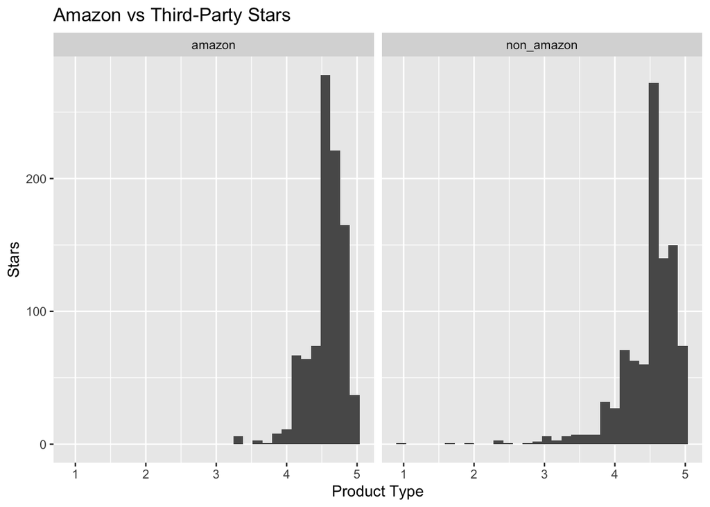

```r
# Filter data
amazon_10 = amazon %>%
  filter(amazon <= 10) %>%
  pull(amazon_stars)

# Note that this has more data points than amazon products
# Take sample of matching length to first one
non_amazon_10 = amazon %>%
  filter(third_party <= 10) %>%
  pull(third_party_stars)

# Merge data
stars = data.frame(
  "amazon" = amazon_10,
  "non_amazon" = sample(non_amazon_10, length(amazon_10))

)

stars = stars %>%
  pivot_longer(cols = 1:2, names_to ="product_type", values_to = "stars")

# Get averages

# Box Plot - also removing outliers
ggplot(stars, aes(x = stars)) +
  geom_histogram(outlier.shape = NA) +
  #coord_cartesian(ylim=c(0, 20000)) +
  ggtitle("Amazon vs Third-Party Stars") +
  xlab("Product Type") +
  ylab("Stars") +
  facet_wrap(vars(product_type))
```

```r
# Use a side by side box plot to showcase this
```

### Question 2

- What is the distribution of positions for Amazon products in search results?

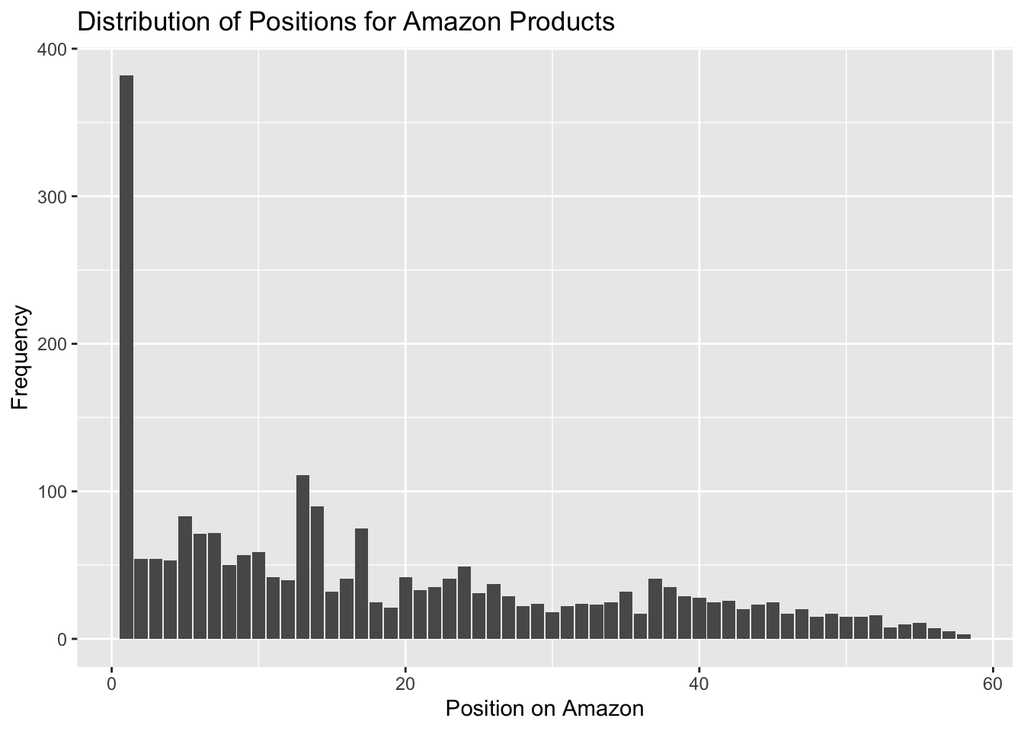

```r
amazon %>%
    ggplot(aes(x=amazon)) +
    geom_bar() +
    ggtitle("Distribution of Positions for Amazon Products") +
    xlab("Position on Amazon") +
    ylab("Frequency")
```

### Question 3

```r
#Graph both side by side (pivot longer?) and use cor(x,y)
#or residual graph? That may be better (look to hw 10 q 5)
#Using cor(x,y), find difference between them and interpret what difference means
```

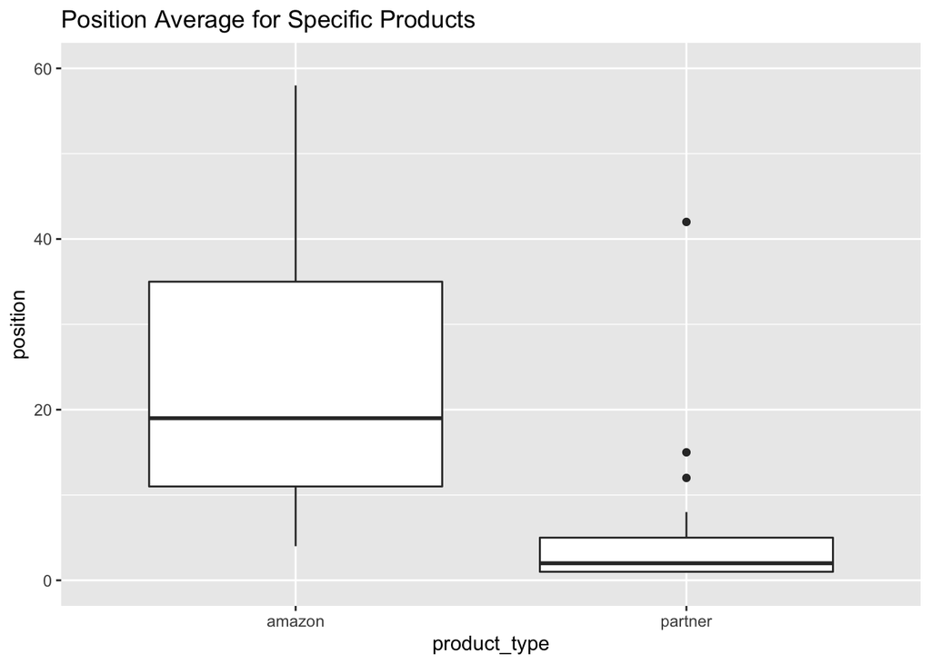

```r
specific_search = amazon %>%
  filter(is_general == "no") %>%
  select(amazon, partner)


specific_search = specific_search %>%
  pivot_longer(cols=1:2, names_to = "product_type", values_to = "position")

ggplot(specific_search, aes(x=product_type, y=position)) +
  geom_boxplot() +
  ylim(0, 60) +
  ggtitle("Position Average for Specific Products")
```

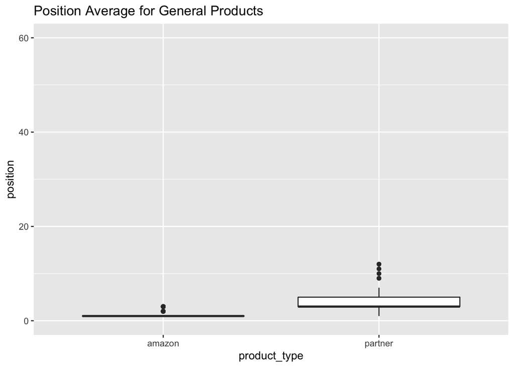

```r
general_search = amazon %>%
  filter(is_general == "yes") %>%
  select(amazon, partner)


general_search = general_search %>%
  pivot_longer(cols=1:2, names_to = "product_type", values_to = "position")


ggplot(general_search, aes(x=product_type, y=position)) +
  geom_boxplot() +
  ylim(0, 60) +
  ggtitle("Position Average for General Products")
```

## Methods

### Question 4

- Hypothesis Test: Are Amazon products on average placed higher than those from third-party sellers?

> We will answer this question by performing a series of mutations on our data in order to calculate two distinct values. First, we will find the difference in values between these two groups, and use these values to search for the true mean between them. In order to do that, we will construct a 95% confidence interval of where we think the true mean resides. Finally, we will calculate a t-statistic and use this to calculate a p-value to show how probable our hypothesized mean is compared to the true mean. For both tests, in order to test if one group is higher than the other, we will first need to test if both groups are similar. To test similarity, we will predict a mean of 0. If 0 is within the 95% confidence interval, we can assume that there is a probable chance it is the true mean. This is similar to our p-value. If the p-value is over 0.05, we can assume that there is a statistically significant chance that our predicted value could be the true mean.

Model
$$X_i \ \sim \ F_1(\mu_1, \sigma_1), i = 1, ..., n_1 \\
Y_i \ \sim \ F_2(\mu_2, \sigma_2), i = 1, ..., n_2$$
Hypothesis test
$$H_0 : \mu_1 = \mu_2 \\
H_a : \mu_1 \ne \mu_2$$
Our test statistic is T

If the null hypothesis is true, then:
$$X_i = Y_i$$

> After our calculations, we have constructed a confidence interval for the mean of our two groups:

```
## # A tibble: 1 × 2
##      low  high
##    <dbl> <dbl>
## 1 -0.366  1.45
```

> We are 95% confident that the average difference in position between amazon products and third party products is between -0.366 and 1.45. Note that this includes 0, which provides evidence supporting the null hypothesis that the two sets of products are similar.

> Next, we calculate the p-value:

```
## [1] 0.2419114
```

> There is a good chance (p = .24) that the mean difference in position between amazon products and third party products is 0.

### Question 5

- Hypothesis Test: Are Amazon partner products on average placed higher than those from third-party sellers?

> We will then repeat our hypothesis test for comparing Third Party products vs Partner products.

Model
$$X_i \ \sim \ F_1(\mu_1, \sigma_1), i = 1, ..., n_1 \\
Y_i \ \sim \ F_2(\mu_2, \sigma_2), i = 1, ..., n_2$$
Hypothesis test
$$H_0 : \mu_1 = \mu_2 \\
H_a : \mu_1 \ne \mu_2$$
Our test statistic is T

If the null hypothesis is true, then:
$$X_i = Y_i$$

> Same as last time, we now construct a confidence interval for the mean of our two groups.

```
## # A tibble: 1 × 2
##     low  high
##   <dbl> <dbl>
## 1  14.0  15.2
```

> We are 95% confident that the mean difference between third party products and partner products is between 14.0 and 15.2. Note that 0 is not within our confidence interval, as opposed to the previous hypothesis test. This, on the other hand, provides evidence contrary to the null hypothesis, which would then suggest that the two sets of products are not similar.

> And again, we calculate our p value to test how probable our hypothesized mean of 0 is when compared to the mean of our dataset.

```
## [1] 0
```

> (Note that the calulated value was so small, our computer was forced to round to 0) We are almost certain (p≈0) that the mean difference between third party products and partner products is not 0.

## Sources:

- https://medium.com/@Shoemaker703/how-does-amazon-select-the-top-product-in-its-search-results-and-why-is-it-usually-one-of-amazons-662d122591d0
- https://github.com/the-markup/investigation-amazon-brands